# Hands-on programming with R: Weighted dice

```r
library(ggplot2)
```

### Create a die (assign values to an object)

Create an object called die that contains a number of values

```r
# Create an object called die that contains the values 1 to 6
die <- 1:6
```

You can do a lot with this vector by adding/subtracting it using element-wise execution (which is not what you would expect in linear algebra)

```r
die * 2
```

```
## [1]  2  4  6  8 10 12
```

You can also give R vectors of unequal length, it will recycle the shorter vector to match the length of the longer vector

```r
die + 1:2
```

```
## [1] 2 4 4 6 6 8
```

### Roll the die (write a function)

Let’s roll the die, the size will determine how many numbers R will sample from the values of die (size argument) and whether it will sample with replacement (replace argument)

```r
dice <- sample(x = die, size = 2, replace = TRUE)
```

Now, add up the dice

```r
# Add up the dice
sum(dice)
```

```
## [1] 2
```

Let’s create a function so we can roll the dice whenever we want. Here we give the argument die a default value from 1 to 6 (die = 1:6).

```r
roll <- function(die = 1:6) {
  dice <- sample(x = die, size = 2, replace = TRUE)
  sum(dice)
}
```

### Roll the dice many times (use the replicate function)

Modify the roll function in such a way so the probability of a number occurring should be higher to that of other numbers (see prob)

```r
roll <- function(){
  die <- 1:6
  dice <- sample(die, size = 2, replace = TRUE, prob = c(1/8,1/8,1/8,1/8,1/8,3/8))
  sum(dice)
}
```

Then replicate rolling the modified dice using the replicate command

```r
rolls <- replicate(10000,roll())
```

### Plot the distribution of the dice (use the qplot command)

Use the qplot function to plot a histogram with a binwidth of 1

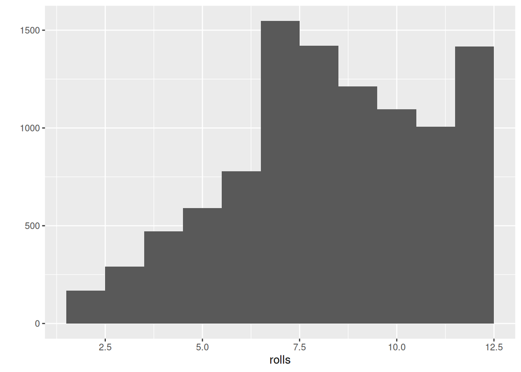

```r
qplot(rolls, binwidth=1)
```